# Computer Science 1

**Computer lab 10**

**Course Number:** BTPS1210BA-E  
**Contact Information:** Please contact me through email anytime: abari.kalman@arts.unideb.hu

Author

Kálmán Abari

Published

August 31, 2024

Learning outcomes

Students will learn how to create a document according to academic writing.

# Word processing - Styles, TOC, Bibliography, APA7

## Problem 1

> In this section, you will learn how to edit text in Word text editor.

Word processing skills are practised by reproducing an article freely available on the Internet. Particular attention will be paid to the preparation of the table of contents and bibliography, and to the correct numbering of pages.

We follow the following rules:

- Text structure on each page: 3 cm top margin, 3 cm bottom margin, 2.5 cm margin on left, 2.5 cm margin on right, TNR 12 font size, 1.5 line spacing.
- Page numbers at bottom centre of page.
- Page numbering of the article begins with the table of contents and ends with the bibliography.
- All tables and figures should be numbered and titled, formatted in [APA7 style](https://apastyle.apa.org/style-grammar-guidelines/tables-figures).
- Format [in-text citation](https://apastyle.apa.org/style-grammar-guidelines/citations) and [bibliography](https://apastyle.apa.org/style-grammar-guidelines/references) in APA7 format.
1. Search the internet for this article: https://www.frontiersin.org/articles/10.3389/fpsyg.2023.1258808/full

[figure not shown]

The source article

2. Launch the Word word processor. Create a new document. Save it as `article_01.docx`.

[figure not shown]

New document

3. Show nonprintable symbols in the Word document. Details [here](https://www.officetooltips.com/word/tips/how_to_show_hide_nonprintable_symbols_in_a_word_document.html).

[figure not shown]

Microsoft Word was designed to hide all the formatting and technicalities (WYSIWYG). Early versions of Word had a **Show All** option but it was hidden away because Microsoft believed their software was so good, such a tool was not necessary. At some point commonsense prevailed and now **Show All** is on the Home tab, Paragraph section. **Show all** is the easy way to see all the underlying formatting to help you figure out what’s happening. Tabs, Section Breaks, Paragraph Marks even Spaces are all exposed by **Show All**.

As with most things in Word, you can use either a keyboard shortcut or the mouse to see the hidden formatting characters.

- Keyboard, hit `Control+Shift+8`.
- Mouse, simply click the Show/Hide button on the Home tab.

4. Show the **Ribbon** in Word. Just press `Ctrl+F1` from your keyboard to show / hide toolbar (ribbon). Details [here](https://support.microsoft.com/en-au/office/show-or-hide-the-ribbon-in-office-d946b26e-0c8c-402d-a0f7-c6efa296b527).

[figure not shown]

Show Ribbon

5. Display the **Ruler** in a Word Document. To show the **Ruler** at the top and left-hand side in a Word Document, click on the **View** tab. Make sure that **Print Layout** is selected under **Views** section. In the **Show** section (second from the left), check the box next to Ruler. Details [here](https://support.microsoft.com/en-us/office/show-the-ruler-dc8a4e0d-209f-43b8-b967-8e65da24d4c7).

[figure not shown]

Show Rulers

6. Show the **Navigation Pane**. To open the Navigation pane, press `Ctrl+F`, or select the **View** tab and choose **Navigation Pane**. In the Navigation pane, select the **Headings** tab.

[figure not shown]

Show Navigation pane - headings tab

7. Show the **Styles** pane. Details [here](https://support.microsoft.com/en-gb/office/add-and-remove-styles-from-the-quick-styles-gallery-21c5b9de-b19e-4575-bc87-cb2b55ece224).

[figure not shown]

Show Styles pane

**Let this be your starting screen for all word processing tasks.**

[figure not shown]

Starting screen before word processing

8. Any text editing process basically consists of 3 parts
   1. Typing the text
   2. Formatting the text
   3. Saving and printing the text

   **Typing is now replaced by using the clipboard.**  
   Copy the title from the article into the word document with `Ctrl+C` and `Ctrl+V`. **After pasting text `Ctrl+V`, press `Ctrl` for paste options to appear and then press `T` for pasting the text with “Keep text only” paste option. We need the text without formatting.**

[figure not shown]

Copy the title

9. Let’s copy the names of the authors.

[figure not shown]

Copy the names of the authors

10. Copy the authors’ affiliation details.

[figure not shown]

Copy the authors’ affiliation details

11. Copy the abstract of the article.

[figure not shown]

Copy the abstract

12. Copy the full text of chapters 1 and 2. To be safe, select the entire document (`Ctrl-A`) and delete all formatting. Details [here](https://support.microsoft.com/en-us/office/clear-all-text-formatting-c094c4da-7f09-4cea-9a8d-c166949c9c80).

[figure not shown]

Copy the full text of chapters 1 and 2

13. Set the language to English. Select the entire document (`Ctrl-A`) and then set on the status bar to English.

[figure not shown]

Set language to English

14. We are now ready to “type” the text. Next comes the formatting. Formatting is done with styles. Details [here](https://support.microsoft.com/en-au/office/customize-or-create-new-styles-d38d6e47-f6fc-48eb-a607-1eb120dec563). Modify the “Title” style as follows:
    - In the Style panel, right-click on the Title style and select Modify.

[figure not shown]

Modify Title style

Select font formatting options.

[figure not shown]

Select Font settings

Modify the “Title” style as follows:

- Font type: Times New Roman
- Font style: Bold
- Font size: 24 pt

[figure not shown]

Settings Fonts

Select paragraph formatting options.

[figure not shown]

Select Paragraph settings

Modify the “Title” style as follows:

- Text alignment: Centered
- Paragraph Spacing, Before: 36 pt
- Paragraph Spacing, After: 136 pt
- Paragraph Spacing, Line Spacing: 1.5 lines

[figure not shown]

Settings Paragraph

15. Apply the “Title” style to the title. Find the title in the text and place the text cursor anywhere in the title text.

[figure not shown]

Text cursor in title

Left-click the “Title” style in the Styles pane.

[figure not shown]

Apply the Title style

16. Create a new style “Author” for formatting authors. Left-click on the ‘New Style’ button in the bottom left corner of the Style pane. The style should be based on ‘Normal’.

[figure not shown]

Create ‘Author’ style

To access the font formatting and paragraph formatting options, use the ‘Formatting’ button, just as you would when changing the ‘Title’ style above. Use the following options:

- Font type: Times New Roman
- Font style: Regular
- Font size: 16 pt
- Text alignment: Centered
- Paragraph Spacing, Before: 12 pt
- Paragraph Spacing, After: 8 pt
- Paragraph Spacing, Line Spacing: 1.5 lines
17. Apply the “Author” style to the authors. Find the authors in the text and place the text cursor anywhere in the authors text. Left-click the “Author” style in the Styles pane.

[figure not shown]

Apply the ‘Author’ style

[figure not shown]

20. Insert a page break (`Ctrl+Enter`) after the afiliation. Details [here](https://support.microsoft.com/en-us/office/insert-or-delete-a-page-break-183d9245-b791-4cd3-9ec2-093258a78a52).

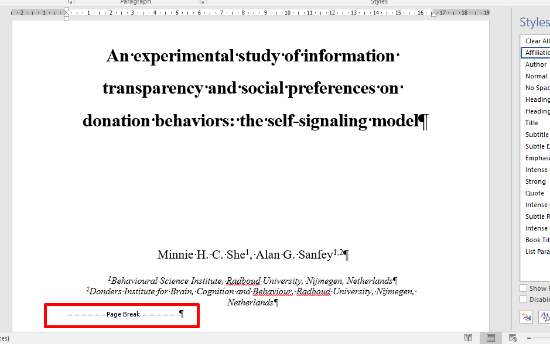

Insert a Page Break

21. Type ‘Abstract’ before the abstract.

[figure not shown]

Type ‘Abstract’ text

22. Create a new style ‘Abstract title’ and apply it to the corresponding text. Features of the new style:
    - Font type: Times New Roman
    - Font style: Bold
    - Font size: 14 pt
    - Text alignment: Left
    - Paragraph Spacing, Before: 0 pt
    - Paragraph Spacing, After: 12 pt
    - Paragraph Spacing, Line Spacing: 1.5 lines

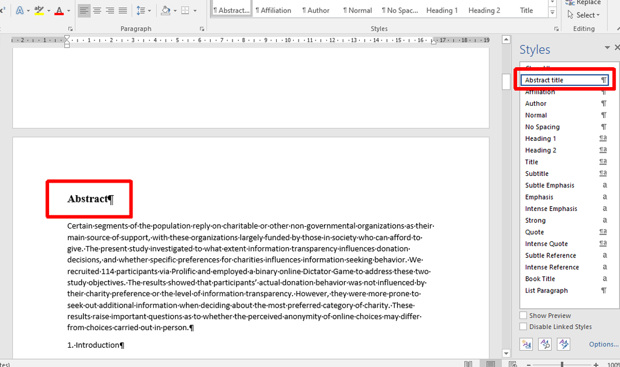

Format ‘Abstract’ text

23. Create a new style ‘Abstract’ and apply it to the corresponding text. Features of the new style:
    - Font type: Times New Roman
    - Font style: Regular
    - Font size: 12 pt
    - Text alignment: Justified
    - Identation, Left: 1 cm
    - Identation, Right: 1 cm
    - Paragraph Spacing, Before: 0 pt
    - Paragraph Spacing, After: 8 pt
    - Paragraph Spacing, Line Spacing: 1.5 lines

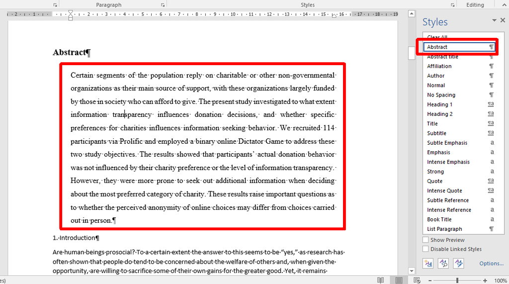

Apply the ‘Abstract’ style

24. Insert a page break (`Ctrl+Enter`) after the abstract. Details [here](https://support.microsoft.com/en-us/office/insert-or-delete-a-page-break-183d9245-b791-4cd3-9ec2-093258a78a52).

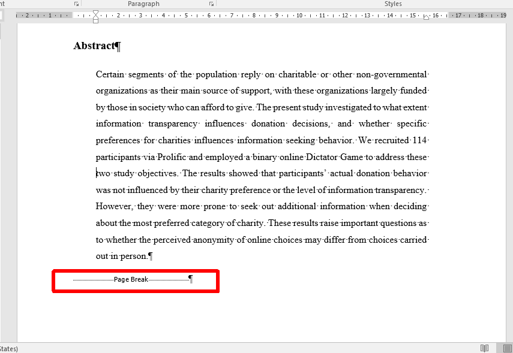

Insert a Page Break

25. Modify the style ‘Header 1’ and apply it to the corresponding text. Features of the style ‘Heading 1’:
    - Font type: Times New Roman
    - Font style: Bold
    - Font size: 18 pt
    - Font color: Automatic
    - Text alignment: Centered
    - Paragraph Spacing, Before: 0 pt
    - Paragraph Spacing, After: 24 pt
    - Paragraph Spacing, Line Spacing: 1.5 lines
    - Line and Page Breaks: Page break before